# Building Hierarchical Transactional Frequency Models

In this workbook we investigate different ways to model the transaction frequency of individual customers, with a view to expanding this approach into a more traditional P/NBD model.

# 1 Load and Configure Datasets

We first want to load some synthetic transaction data.

```r
customer_cohort_tbl <- read_rds("data/synthdata_singleyear_cohort_tbl.rds")
customer_cohort_tbl %>% glimpse()
```

```
## Rows: 50,000
## Columns: 4
## $ customer_id    <chr> "8JRWQHAXGE", "8D1JREK9KR", "OXUF71I25Q", "1SCZ4QOQ4Y",…
## $ cohort_qtr     <chr> "2019 Q1", "2019 Q1", "2019 Q1", "2019 Q1", "2019 Q1", …
## $ cohort_ym      <chr> "2019 01", "2019 01", "2019 01", "2019 01", "2019 01", …
## $ first_tnx_date <date> 2019-01-01, 2019-01-01, 2019-01-01, 2019-01-01, 2019-0…
```

```r
customer_simparams_tbl <- read_rds("data/synthdata_singleyear_simparams_tbl.rds")
customer_simparams_tbl %>% glimpse()
```

```
## Rows: 50,000
## Columns: 8
## $ customer_id     <chr> "000JSNK3XH", "001A7TLTYV", "004GMUBSCD", "004LAX8P44"…
## $ cohort_qtr      <chr> "2019 Q1", "2019 Q1", "2019 Q1", "2019 Q1", "2019 Q1",…
## $ cohort_ym       <chr> "2019 01", "2019 01", "2019 01", "2019 01", "2019 01",…
## $ first_tnx_date  <date> 2019-01-01, 2019-01-01, 2019-01-01, 2019-01-01, 2019-…
## $ customer_tau    <dbl> 53, 53, 53, 53, 53, 53, 53, 53, 53, 53, 53, 53, 53, 53…
## $ customer_lambda <dbl> 0.63746283, 0.05247298, 0.06824901, 0.20599461, 1.1217…
## $ customer_nu     <dbl> 0.449753057, 0.456665157, 0.263130590, 0.007679448, 1.…
## $ customer_p      <dbl> 100, 100, 100, 100, 100, 100, 100, 100, 100, 100, 100,…
```

```r
customer_transactions_tbl <- read_rds("data/synthdata_singleyear_transactions_tbl.rds")
customer_transactions_tbl %>% glimpse()
```

```
## Rows: 919,470
## Columns: 5
## $ customer_id   <chr> "000JSNK3XH", "000JSNK3XH", "000JSNK3XH", "000JSNK3XH", …
## $ cohort_qtr    <chr> "2019 Q1", "2019 Q1", "2019 Q1", "2019 Q1", "2019 Q1", "…
## $ cohort_ym     <chr> "2019 01", "2019 01", "2019 01", "2019 01", "2019 01", "…
## $ tnx_timestamp <dttm> 2019-01-01 19:52:38, 2019-01-16 20:04:48, 2019-01-23 23…
## $ tnx_amount    <dbl> 234.83, 213.38, 214.90, 180.31, 234.99, 245.72, 226.07, …
```

```r
customer_summarystats_tbl <- read_rds("data/synthdata_singleyear_summarystats_tbl.rds")
customer_summarystats_tbl %>% glimpse()
```

```
## Rows: 50,000
## Columns: 9
## $ customer_id  <chr> "000JSNK3XH", "001A7TLTYV", "004GMUBSCD", "004LAX8P44", "…
## $ tnx_count    <int> 29, 3, 2, 16, 60, 9, 42, 2, 7, 132, 27, 2, 10, 3, 13, 5, …
## $ first_tnx_ts <dttm> 2019-01-01 19:52:38, 2019-01-01 01:53:18, 2019-01-01 18:…
## $ last_tnx_ts  <dttm> 2019-11-19 10:48:17, 2019-12-25 16:49:55, 2019-08-20 05:…
## $ btyd_count   <dbl> 28, 2, 1, 15, 59, 8, 41, 1, 6, 131, 26, 1, 9, 2, 12, 4, 1…
## $ all_weeks    <dbl> 52, 52, 52, 52, 52, 52, 52, 52, 52, 52, 52, 52, 52, 52, 5…
## $ tnx_weeks    <dbl> 45.94600, 51.23181, 32.91996, 50.42715, 51.90082, 45.4073…
## $ obs_freq     <dbl> 0.60941109, 0.03903825, 0.03037671, 0.29745883, 1.1367836…
## $ emp_freq     <dbl> 0.53846154, 0.03846154, 0.01923077, 0.28846154, 1.1346153…
```

We also want to set up a number of parameters for use in this workbook

```r
stan_modeldir <- "stan_models"
stan_codedir  <-   "stan_code"
```

We also want to load the subset of `customer_id` so it is consistent with the previous workbooks

```r
id_1000  <- read_rds("data/id_1000.rds")
id_5000  <- read_rds("data/id_5000.rds")
id_10000 <- read_rds("data/id_10000.rds")
```

We now want to construct data used to fit the models.

```r
fit_1000_data_tbl <- customer_summarystats_tbl %>%
  filter(
    customer_id %in% id_1000
    )

fit_1000_data_tbl %>% glimpse()
```

```
## Rows: 1,000
## Columns: 9
## $ customer_id  <chr> "00RC3IE4XG", "02NO5FZ0VS", "02RE0JNCFQ", "04COTHYBKJ", "…
## $ tnx_count    <int> 4, 2, 53, 19, 1, 4, 27, 16, 25, 21, 16, 46, 16, 2, 8, 5, …
## $ first_tnx_ts <dttm> 2019-01-01 08:59:28, 2019-01-01 06:23:37, 2019-01-01 04:…
## $ last_tnx_ts  <dttm> 2019-07-30 12:39:28, 2019-02-18 02:35:37, 2019-12-15 16:…
## $ btyd_count   <dbl> 3, 1, 52, 18, 0, 3, 26, 15, 24, 20, 15, 45, 15, 1, 7, 4, …
## $ all_weeks    <dbl> 52, 52, 52, 52, 52, 52, 52, 52, 52, 52, 52, 52, 52, 52, 5…
## $ tnx_weeks    <dbl> 30.021826, 6.834524, 49.786903, 51.422187, 52.000000, 45.…
## $ obs_freq     <dbl> 0.09992730, 0.14631596, 1.04445139, 0.35004346, 0.0000000…
## $ emp_freq     <dbl> 0.05769231, 0.01923077, 1.00000000, 0.34615385, 0.0000000…
```

```r
fit_10000_data_tbl <- customer_summarystats_tbl %>%
  filter(
    customer_id %in% id_10000
    )

fit_10000_data_tbl %>% glimpse()
```

```
## Rows: 10,000
## Columns: 9
## $ customer_id  <chr> "000JSNK3XH", "004LAX8P44", "0068WIE4X2", "00O7MNGPZC", "…
## $ tnx_count    <int> 29, 16, 9, 43, 11, 4, 6, 4, 1, 7, 26, 7, 2, 9, 9, 11, 11,…
## $ first_tnx_ts <dttm> 2019-01-01 19:52:38, 2019-01-01 23:38:35, 2019-01-01 12:…
## $ last_tnx_ts  <dttm> 2019-11-19 10:48:17, 2019-12-20 23:24:14, 2019-11-15 09:…
## $ btyd_count   <dbl> 28, 15, 8, 42, 10, 3, 5, 3, 0, 6, 25, 6, 1, 8, 8, 10, 10,…
## $ all_weeks    <dbl> 52, 52, 52, 52, 52, 52, 52, 52, 52, 52, 52, 52, 52, 52, 5…
## $ tnx_weeks    <dbl> 45.945997, 50.427147, 45.407391, 51.975108, 47.378704, 30…
## $ obs_freq     <dbl> 0.60941109, 0.29745883, 0.17618277, 0.80807913, 0.2110652…
## $ emp_freq     <dbl> 0.53846154, 0.28846154, 0.15384615, 0.80769231, 0.1923076…
```

## 1.1 Load Frequency Data

We also wish to load the frequency summary data as we use this for a number of modelling tasks.

```r
customer_summarystats_tbl <- read_rds("data/customer_summarystats_tbl.rds")
customer_summarystats_tbl %>% glimpse()
```

```
## Rows: 50,000
## Columns: 9
## $ customer_id  <chr> "000JSNK3XH", "001A7TLTYV", "004GMUBSCD", "004LAX8P44", "…
## $ tnx_count    <int> 29, 3, 2, 16, 60, 9, 42, 2, 7, 132, 27, 2, 10, 3, 13, 5, …
## $ first_tnx_ts <dttm> 2019-01-01 19:52:38, 2019-01-01 01:53:18, 2019-01-01 18:…
## $ last_tnx_ts  <dttm> 2019-11-19 10:48:17, 2019-12-25 16:49:55, 2019-08-20 05:…
## $ btyd_count   <dbl> 28, 2, 1, 15, 59, 8, 41, 1, 6, 131, 26, 1, 9, 2, 12, 4, 1…
## $ all_weeks    <dbl> 52, 52, 52, 52, 52, 52, 52, 52, 52, 52, 52, 52, 52, 52, 5…
## $ tnx_weeks    <dbl> 45.94600, 51.23181, 32.91996, 50.42715, 51.90082, 45.4073…
## $ obs_freq     <dbl> 0.60941109, 0.03903825, 0.03037671, 0.29745883, 1.1367836…
## $ emp_freq     <dbl> 0.53846154, 0.03846154, 0.01923077, 0.28846154, 1.1346153…
```

```r
nonhier_comparison_distrib_tbl <- read_rds("data/customer_comparison_distrib_tbl.rds")
nonhier_comparison_distrib_tbl %>% glimpse()
```

```
## Rows: 6,000,000
## Columns: 5
## $ label           <chr> "Flat", "Flat", "Flat", "Flat", "Flat", "Flat", "Flat"…
## $ customer_id     <chr> "00RC3IE4XG", "00RC3IE4XG", "00RC3IE4XG", "00RC3IE4XG"…
## $ draw_id         <int> 1, 2, 3, 4, 5, 6, 7, 8, 9, 10, 11, 12, 13, 14, 15, 16,…
## $ post_lambda     <dbl> 0.1511800, 0.0799502, 0.2983930, 0.0345082, 0.0995931,…
## $ customer_lambda <dbl> 0.05118089, 0.05118089, 0.05118089, 0.05118089, 0.0511…
```

# 2 Construct Hierarchical Frequency Model

In our previous models we fixed the parameters for our Gamma hyper-distribution and passed those values in as ‘data’ to the model.

While this worked from a fitting perspective, it has the problem that it required a strong knowledge of what those parameters should be, whereas a more Bayesian approach would instead be to capture this uncertainty by putting distributions around those parameters.

This issue leads to another concern when dealing with fitting probability distributions: the parameters are often co-dependent. This is because, unlike some of the more common distributions, many distributions are not naturally parametrised by location parameters.

Instead, we often try to fit distributions using location and dispersion, and then convert these back to the standard parametrisation.

For the Gamma distribution, we can fit a location parameter $\mu$ and the co-efficient of variation $\nu$ (the standard-deviation divided by the mean). These then convert to the shape parameter $r$ and rate parameter $\alpha$ using the following relationship:

$$\begin{eqnarray*}
r &=& \frac{1}{\nu^2} \\
\alpha &=& \frac{1}{\mu \nu^2}
\end{eqnarray*}$$

We do this in Stan by using the `transformed parameters` block to convert $(\mu, \nu)$ into $(r, \alpha)$, so we can use those fitting the models.

```
## data {
##   int<lower=1> n;               // count of observations
##
##   int<lower=0> btyd_count[n];   // observed number of transactions
##   vector<lower=0>[n] tnx_weeks; // observed time-period of transactions
##
##   real<lower=0> mu_p1, mu_p2;
##   real<lower=0> cov_p1, cov_p2;
## }
##
## parameters {
##   real<lower=0> hier_mu;
##   real<lower=0> hier_cov;
##
##   vector<lower=0>[n] lambda;
## }
##
## transformed parameters {
##   // shape <- 1 / (cv^2)
##   // scale <- mu * cv^2
##
##   real<lower=0> r     = 1 / (hier_cov * hier_cov);
##   real<lower=0> alpha = 1 / (hier_mu  * hier_cov * hier_cov);
## }
##
##
## model {
##   hier_mu  ~ gamma(mu_p1,  mu_p1);
##   hier_cov ~ gamma(cov_p1, cov_p2);
##
##   lambda ~ gamma(r, alpha);
##
##   target += poisson_lpmf(btyd_count | lambda .* tnx_weeks);
## }
```

We now need to think about the parameters for the hierarchical priors, so once again we try something like we had before.

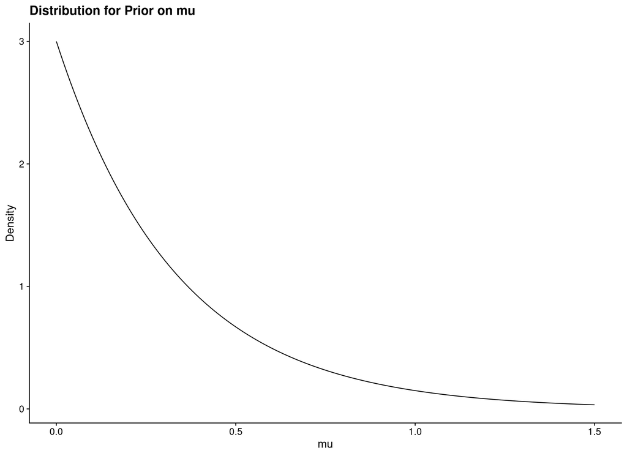

```r
x_vals <- seq(0, 1.5, by = 0.01)
y_vals <- dgamma(x_vals, shape = 1, rate = 3)

ggplot() +
  geom_line(aes(x = x_vals, y = y_vals)) +
  labs(
    x = "mu",
    y = "Density",
    title = "Distribution for Prior on mu"
    )
```

This gives us a good spread of values and so should work fine.

We do a similar task for the spread of values of the co-efficient of variation, which we will estimate to be around 1.

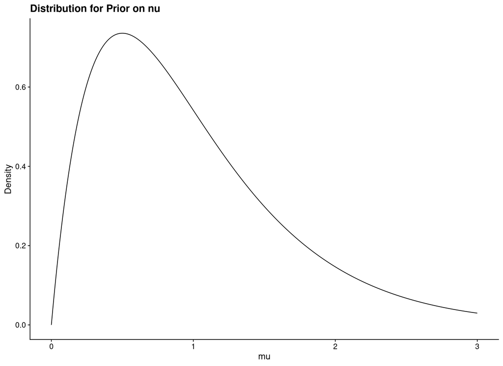

```r
x_vals <- seq(0, 3, by = 0.01)
y_vals <- dgamma(x_vals, shape = 2, rate = 2)

ggplot() +
  geom_line(aes(x = x_vals, y = y_vals)) +
  labs(
    x = "mu",
    y = "Density",
    title = "Distribution for Prior on nu"
    )
```

## 2.1 Compile and Fit First Hierarchical Model

We first need to compile this fitted model.

```r
freqmodel_hier_stanmodel <- cmdstan_model(
  "stan_code/freqmodel_hier.stan",
  include_paths = stan_codedir,
  pedantic      =  TRUE,
  dir           = stan_modeldir
  )
```

We then use this compiled model with our data to produce a fit of the data.

```r
stan_modelname <- "freqmodel_hier"

stan_data_lst <- fit_1000_data_tbl %>%
  select(customer_id, btyd_count, tnx_weeks = all_weeks) %>%
  compose_data(
    mu_p1 = 1,
    mu_p2 = 2,

    cov_p1 = 2,
    cov_p2 = 2
    )

freqmodel_hier_stanfit <- freqmodel_hier_stanmodel$sample(
  data            =        stan_data_lst,
  chains          =                    4,
  iter_warmup     =                  500,
  iter_sampling   =                  500,
  seed            =                  421,
  output_dir      =        stan_modeldir,
  output_basename =       stan_modelname
  )
```

```
## Running MCMC with 4 parallel chains...
##
## Chain 1 Iteration:   1 / 1000 [  0%]  (Warmup)
## Chain 2 Iteration:   1 / 1000 [  0%]  (Warmup)
## Chain 3 Iteration:   1 / 1000 [  0%]  (Warmup)
## Chain 4 Iteration:   1 / 1000 [  0%]  (Warmup)
## Chain 1 Iteration: 100 / 1000 [ 10%]  (Warmup)
## Chain 4 Iteration: 100 / 1000 [ 10%]  (Warmup)
## Chain 1 Iteration: 200 / 1000 [ 20%]  (Warmup)
## Chain 2 Iteration: 100 / 1000 [ 10%]  (Warmup)
## Chain 3 Iteration: 100 / 1000 [ 10%]  (Warmup)
## Chain 4 Iteration: 200 / 1000 [ 20%]  (Warmup)
## Chain 1 Iteration: 300 / 1000 [ 30%]  (Warmup)
## Chain 2 Iteration: 200 / 1000 [ 20%]  (Warmup)
## Chain 1 Iteration: 400 / 1000 [ 40%]  (Warmup)
## Chain 3 Iteration: 200 / 1000 [ 20%]  (Warmup)
## Chain 4 Iteration: 300 / 1000 [ 30%]  (Warmup)
## Chain 2 Iteration: 300 / 1000 [ 30%]  (Warmup)
## Chain 1 Iteration: 500 / 1000 [ 50%]  (Warmup)
## Chain 1 Iteration: 501 / 1000 [ 50%]  (Sampling)
## Chain 2 Iteration: 400 / 1000 [ 40%]  (Warmup)
## Chain 4 Iteration: 400 / 1000 [ 40%]  (Warmup)
## Chain 3 Iteration: 300 / 1000 [ 30%]  (Warmup)
## Chain 4 Iteration: 500 / 1000 [ 50%]  (Warmup)
## Chain 4 Iteration: 501 / 1000 [ 50%]  (Sampling)
## Chain 1 Iteration: 600 / 1000 [ 60%]  (Sampling)
## Chain 2 Iteration: 500 / 1000 [ 50%]  (Warmup)
## Chain 2 Iteration: 501 / 1000 [ 50%]  (Sampling)
## Chain 3 Iteration: 400 / 1000 [ 40%]  (Warmup)
## Chain 4 Iteration: 600 / 1000 [ 60%]  (Sampling)
## Chain 2 Iteration: 600 / 1000 [ 60%]  (Sampling)
## Chain 1 Iteration: 700 / 1000 [ 70%]  (Sampling)
## Chain 3 Iteration: 500 / 1000 [ 50%]  (Warmup)
## Chain 3 Iteration: 501 / 1000 [ 50%]  (Sampling)
## Chain 4 Iteration: 700 / 1000 [ 70%]  (Sampling)
## Chain 2 Iteration: 700 / 1000 [ 70%]  (Sampling)
## Chain 1 Iteration: 800 / 1000 [ 80%]  (Sampling)
## Chain 2 Iteration: 800 / 1000 [ 80%]  (Sampling)
## Chain 3 Iteration: 600 / 1000 [ 60%]  (Sampling)
## Chain 4 Iteration: 800 / 1000 [ 80%]  (Sampling)
## Chain 1 Iteration: 900 / 1000 [ 90%]  (Sampling)
## Chain 2 Iteration: 900 / 1000 [ 90%]  (Sampling)
## Chain 4 Iteration: 900 / 1000 [ 90%]  (Sampling)
## Chain 3 Iteration: 700 / 1000 [ 70%]  (Sampling)
## Chain 1 Iteration: 1000 / 1000 [100%]  (Sampling)
## Chain 2 Iteration: 1000 / 1000 [100%]  (Sampling)
## Chain 4 Iteration: 1000 / 1000 [100%]  (Sampling)
## Chain 1 finished in 7.8 seconds.
## Chain 2 finished in 7.8 seconds.
## Chain 4 finished in 7.7 seconds.
## Chain 3 Iteration: 800 / 1000 [ 80%]  (Sampling)
## Chain 3 Iteration: 900 / 1000 [ 90%]  (Sampling)
## Chain 3 Iteration: 1000 / 1000 [100%]  (Sampling)
## Chain 3 finished in 9.0 seconds.
##
## All 4 chains finished successfully.
## Mean chain execution time: 8.1 seconds.
## Total execution time: 9.3 seconds.
```

```r
freqmodel_hier_stanfit$summary()
```

```
## # A tibble: 1,005 × 10
##    variable       mean   median      sd     mad       q5      q95  rhat ess_bulk
##    <chr>         <dbl>    <dbl>   <dbl>   <dbl>    <dbl>    <dbl> <dbl>    <dbl>
##  1 lp__       -4.10e+3 -4.10e+3 23.2    23.4    -4.14e+3 -4.06e+3  1.00     840.
##  2 hier_mu     3.28e-1  3.28e-1  0.0106  0.0108  3.11e-1  3.45e-1  1.00    2901.
##  3 hier_cov    9.84e-1  9.83e-1  0.0219  0.0214  9.48e-1  1.02e+0  1.00    1354.
##  4 lambda[1]   7.22e-2  6.54e-2  0.0367  0.0341  2.46e-2  1.42e-1  1.00    2365.
##  5 lambda[2]   3.70e-2  3.04e-2  0.0273  0.0224  6.12e-3  8.90e-2  1.00    2045.
##  6 lambda[3]   9.63e-1  9.56e-1  0.130   0.130   7.58e-1  1.19e+0  1.00    2710.
##  7 lambda[4]   3.44e-1  3.40e-1  0.0788  0.0787  2.28e-1  4.87e-1  1.00    2266.
##  8 lambda[5]   1.83e-2  1.26e-2  0.0180  0.0129  1.00e-3  5.39e-2  1.00    2161.
##  9 lambda[6]   7.36e-2  6.69e-2  0.0358  0.0328  2.71e-2  1.39e-1  1.00    2637.
## 10 lambda[7]   4.89e-1  4.85e-1  0.0918  0.0882  3.44e-1  6.53e-1  1.00    2738.
## # … with 995 more rows, and 1 more variable: ess_tail <dbl>
```

# 3 R Environment

```r
options(width = 120L)
```

```r
options(width = 80L)
```